# HMEQ Loan Default: PCA, t-SNE & Cluster Analysis

# Loan Default Prediction — PCA, t-SNE, and Cluster Analysis (HMEQ Dataset)

Dimensionality-reduction and clustering case study on the HMEQ home equity loan dataset, comparing how well Decision Trees, Random Forests, GBM, and Logistic Regression predict **loan default (`TARGET_BAD_FLAG`)** and **loss amount (`TARGET_LOSS_AMT`)** when built on the original variables versus on PCA/t-SNE–reduced features, and using PCA + K-Means to segment borrowers into interpretable risk groups.

This repository packages two related course assignments into a single, reproducible R project:

|  | Focus | Scripts |
| --- | --- | --- |
| **Part 1** | PCA & t-SNE for dimensionality reduction and predictive modeling | `scripts/01`–`05` |
| **Part 2** | PCA + K-Means clustering to segment borrowers | `scripts/06` |

## Reports

- `report.html` — a pre-built, standalone HTML report (this README rendered with all figures embedded) — just open it in a browser, no R required.
- `report.Rmd` — the reproducible R Markdown source. Knit it yourself (`rmarkdown::render("report.Rmd")`) any time you update the data or scripts to regenerate a fresh report.

## Repository structure

```
.
├── README.md
├── LICENSE
├── .gitignore
├── report.Rmd                # R Markdown source -> knit for a fresh HTML report
├── report.html               # pre-built standalone HTML report (open directly, no R needed)
├── data/
│   └── README.md            # where to put the HMEQ CSV (not included)
├── scripts/
│   ├── run_all.R             # runs 01-05 end to end
│   ├── 01_baseline_models.R  # Decision Tree / Random Forest / GBM, classification + regression
│   ├── 02_pca_analysis.R     # PCA on continuous predictors
│   ├── 03_tsne_analysis.R    # t-SNE at perplexity 5 / 30 / 80
│   ├── 04_models_original_data.R      # Tree + stepwise logistic regression, full feature set
│   ├── 05_models_pca_tsne_data.R      # Same models, PCA/t-SNE features only
│   └── 06_cluster_analysis.R # PCA + K-Means clustering + cluster-explaining tree
└── figures/                  # exported plots referenced below
```

## Data

A small synthetic dataset with the right schema is included at `data/sample_HMEQ_Processed.csv` so the pipeline runs out of the box — see `data/README.md` to use it (`cp` it to `data/HMEQ_Processed.csv`). Its values are randomly generated and carry no real signal; swap in the real HMEQ data for meaningful results.

The scripts expect a processed HMEQ file at `data/HMEQ_Processed.csv` — the output of a prior cleaning step (imputed missing values with paired `IMP_*` / `M_*` missing-flag columns, and one-hot encoded `JOB` / `REASON` into `FLAG.Job.*` / `FLAG.Reason.*` columns). The original assignment loaded this interactively with `file.choose()`; the scripts here use a fixed relative path instead so the whole pipeline can be run non-interactively. See `data/README.md` for details and swap in the raw [HMEQ dataset](https://www.kaggle.com/datasets/ajay1735/hmeq-data) plus your own imputation step if you don’t already have a processed copy.

## Requirements

R (≥ 4.0) and the following packages:

```r
install.packages(c(
  "rpart", "rpart.plot", "randomForest", "gbm",
  "ggplot2", "Rtsne", "pROC",
  "dplyr", "tidyverse", "readr",
  "cluster", "factoextra", "flexclust"
))
```

## Running

```bash
# Part 1: baseline models -> PCA -> t-SNE -> modeling comparison
Rscript scripts/run_all.R

# Part 2: PCA + K-Means clustering (independent, reloads its own data)
Rscript scripts/06_cluster_analysis.R
```

Each script can also be run/sourced individually in an interactive R session; scripts `02`–`05` assume `df` (with the columns added by the previous step) is already in the environment.

## Part 1 — PCA & t-SNE for Predictive Modeling

### Step 1: Baseline models on the original data

Decision Tree, Random Forest, and GBM models were fit for both the classification target (`TARGET_BAD_FLAG`) and the regression target (`TARGET_LOSS_AMT`, restricted to defaulted loans).

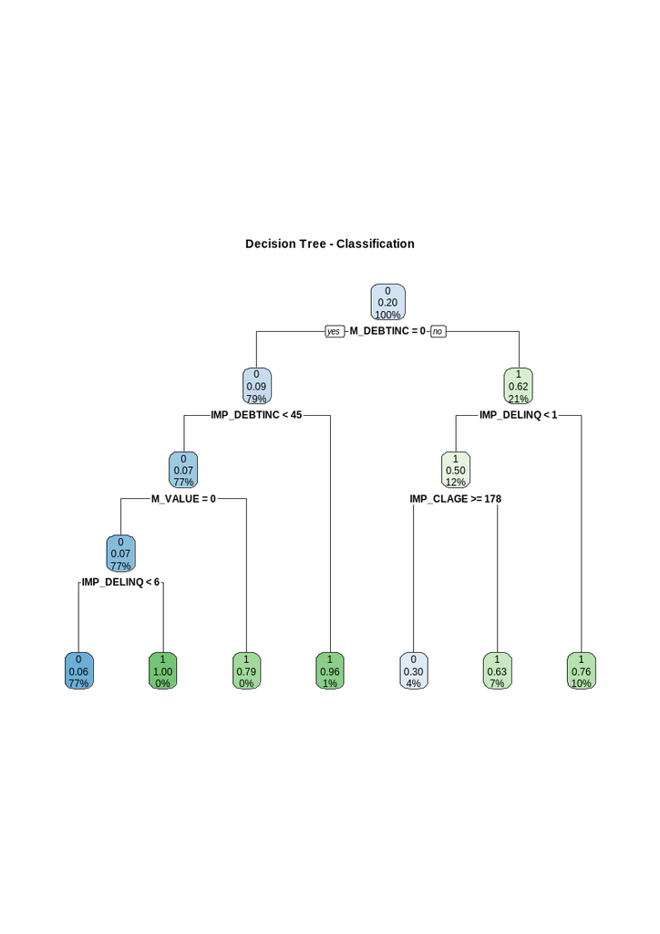

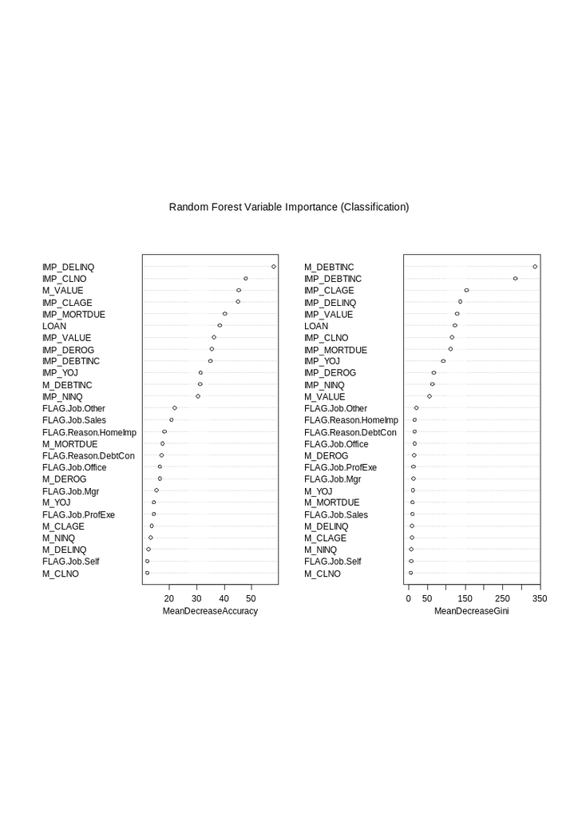

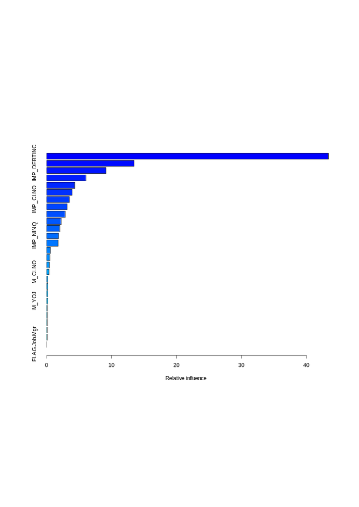

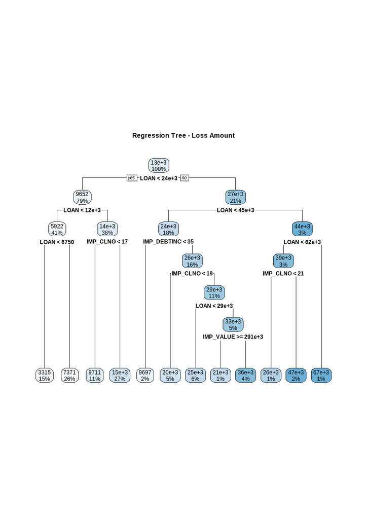

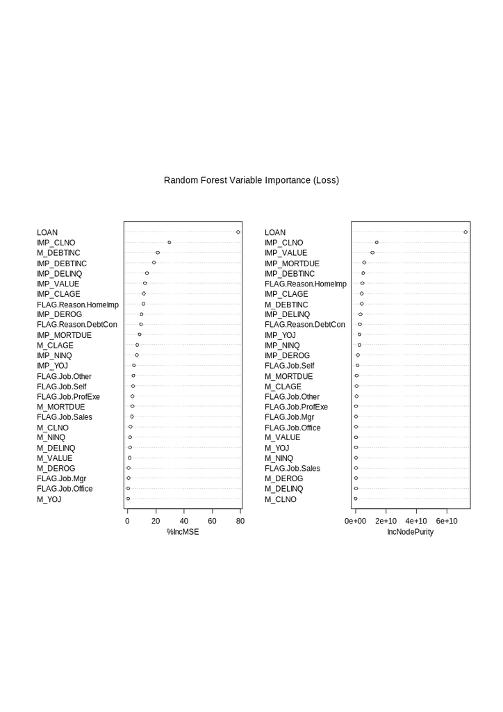

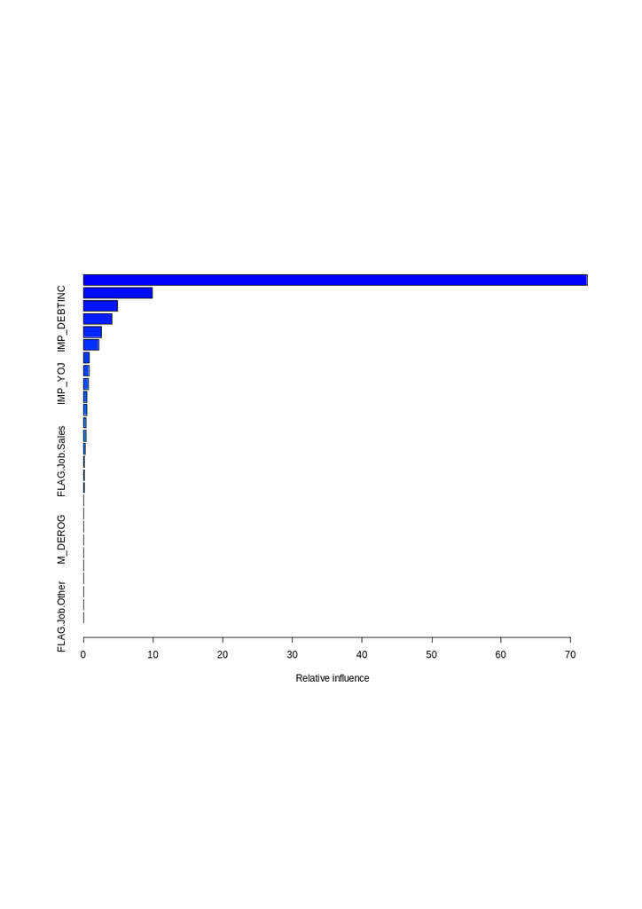

Across all three classification models, debt-to-income ratio (`M_DEBTINC` / `IMP_DEBTINC`), delinquency history (`IMP_DELINQ`), and credit age (`IMP_CLAGE`) consistently ranked as the strongest predictors of default. For the loss-amount regression, `LOAN` (the loan amount itself) dominated variable importance, followed by number of credit lines and debt-to-income ratio.

### Step 2: PCA Analysis

PCA was applied to the continuous, non-flag predictors (after removing the two target columns).

Scree Plot

PC1 vs PC2 by Default Status

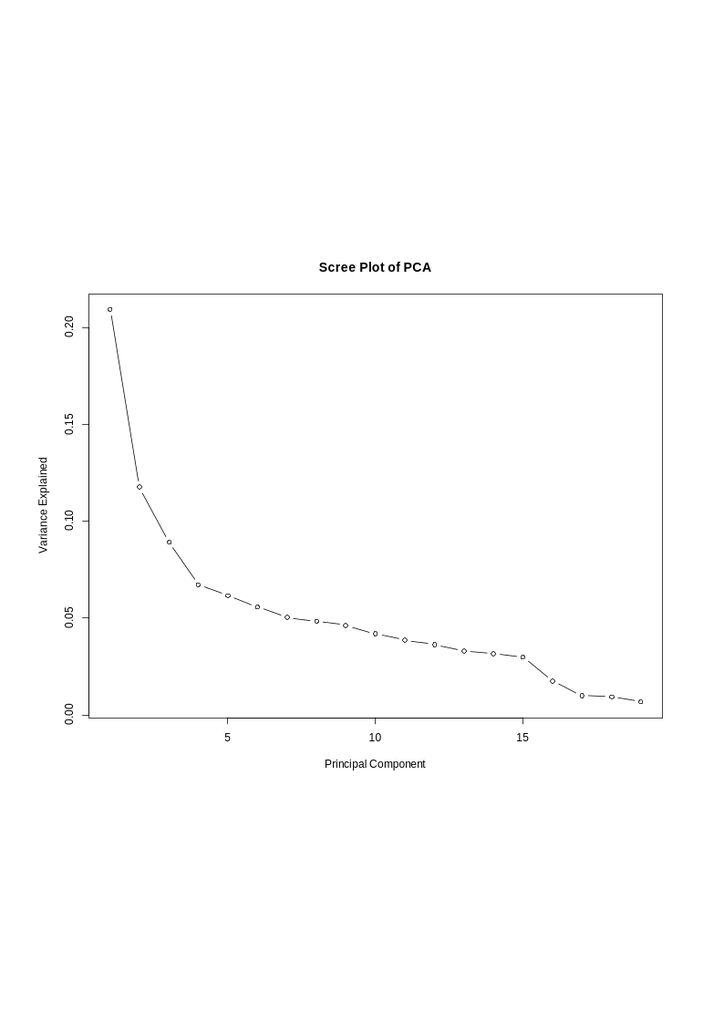

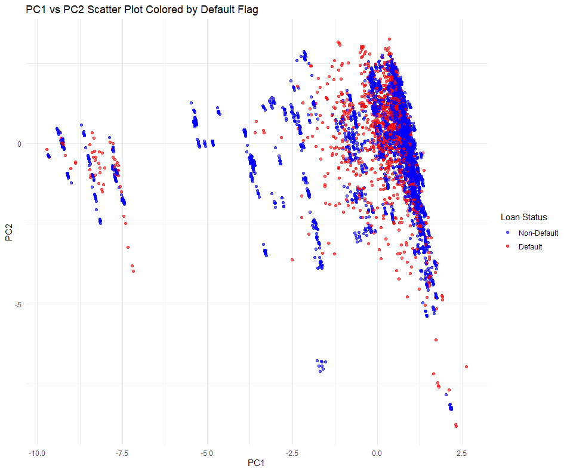

Variance explained drops off gradually rather than showing one or two dominant components, meaning the underlying financial variables are only moderately correlated. In the PC1–PC2 plane, defaulted and non-defaulted borrowers overlap heavily, with only a loose tendency for defaults to sit toward higher PC1 values — PCA alone does not cleanly separate the two classes.

### Step 3: t-SNE Analysis

t-SNE was run at three perplexity settings on the same continuous variables to check whether a nonlinear embedding reveals structure that PCA misses.

Perplexity = 5

Perplexity = 30

Perplexity = 80

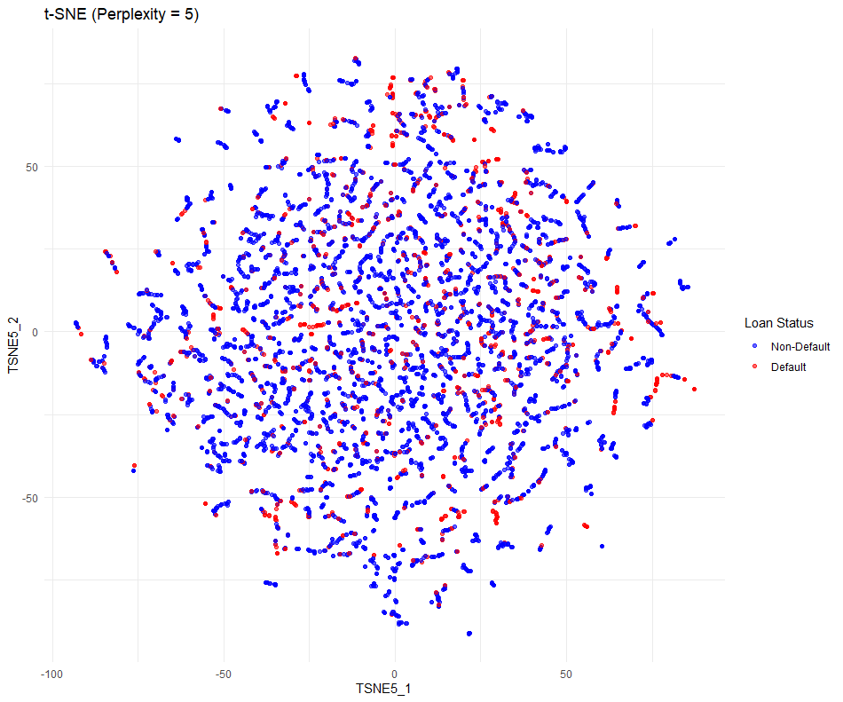

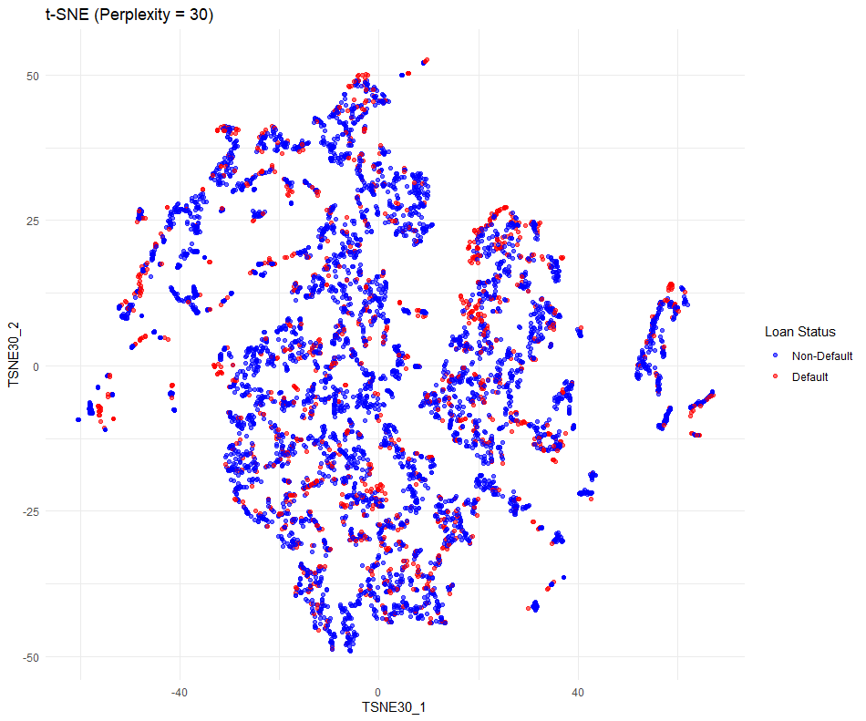

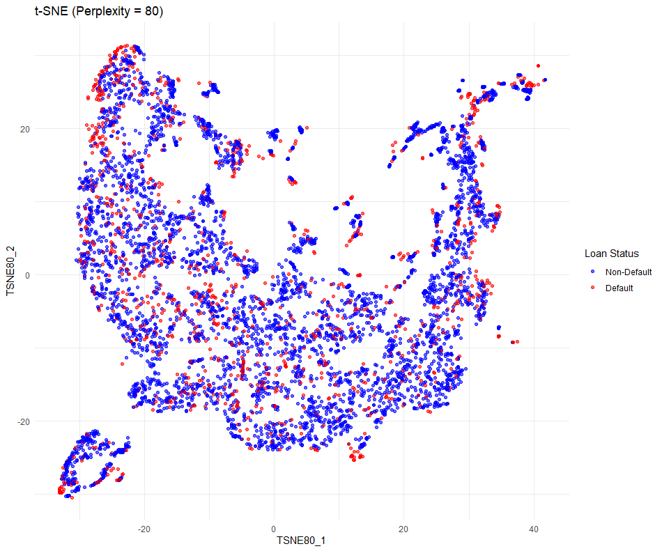

At every perplexity, default and non-default points remain intermixed rather than forming separate clusters. Lower perplexity (5) produces many small, fragmented local groupings; higher perplexity (80) produces a smoother, more global layout — but neither setting yields a boundary that visually separates the two loan-status classes. A quick Random Forest check confirmed the t-SNE coordinates are themselves predictable from the original variables (i.e., they encode real structure, just not one that aligns with the default label).

### Step 4: Modeling on the Original Data (+ PCA/t-SNE columns)

A classification tree and a stepwise logistic regression were fit using the full feature set — original variables plus the PCA and t-SNE columns generated in Steps 2–3.

Decision Tree

ROC Curve

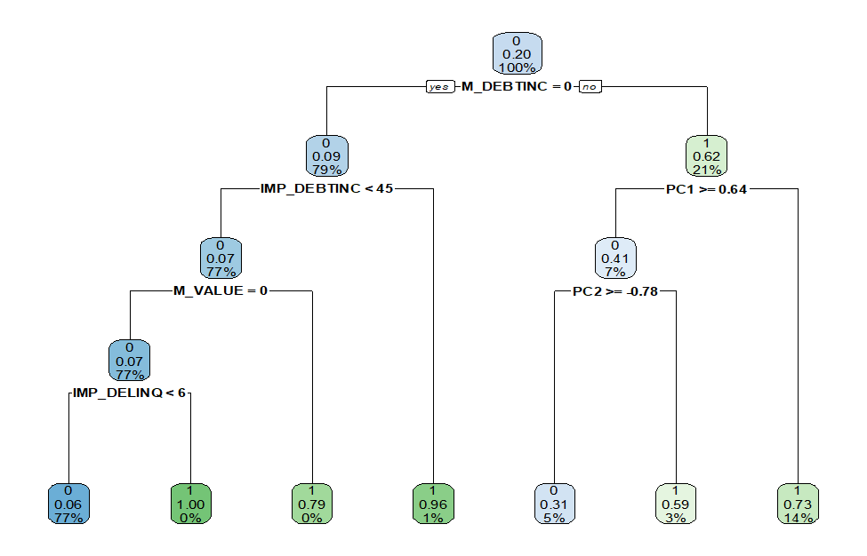

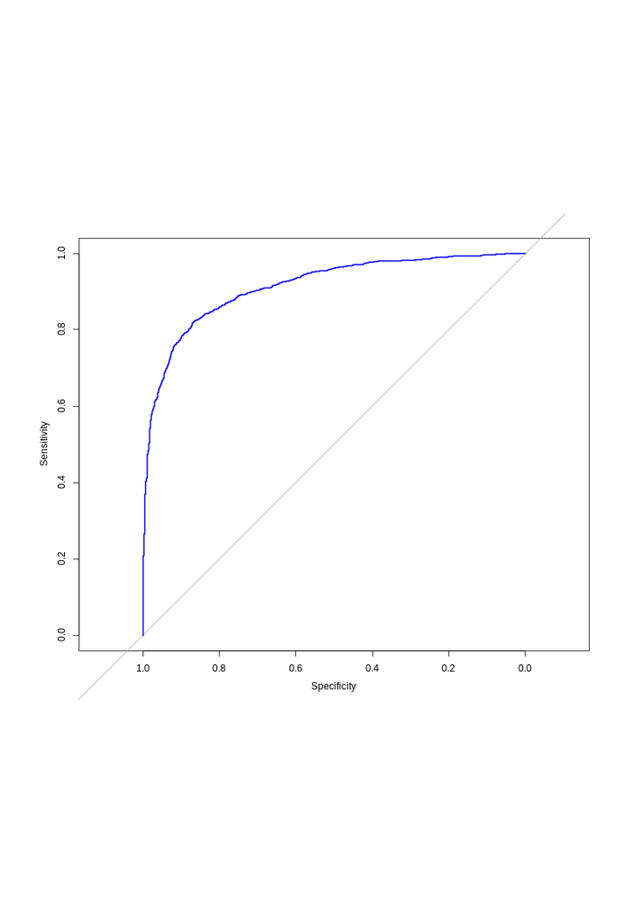

### Step 5: Modeling on PCA/t-SNE Features Only

The same model types were refit after dropping every original continuous variable, keeping only PC1, PC2, the three t-SNE embeddings, and the categorical flag columns.

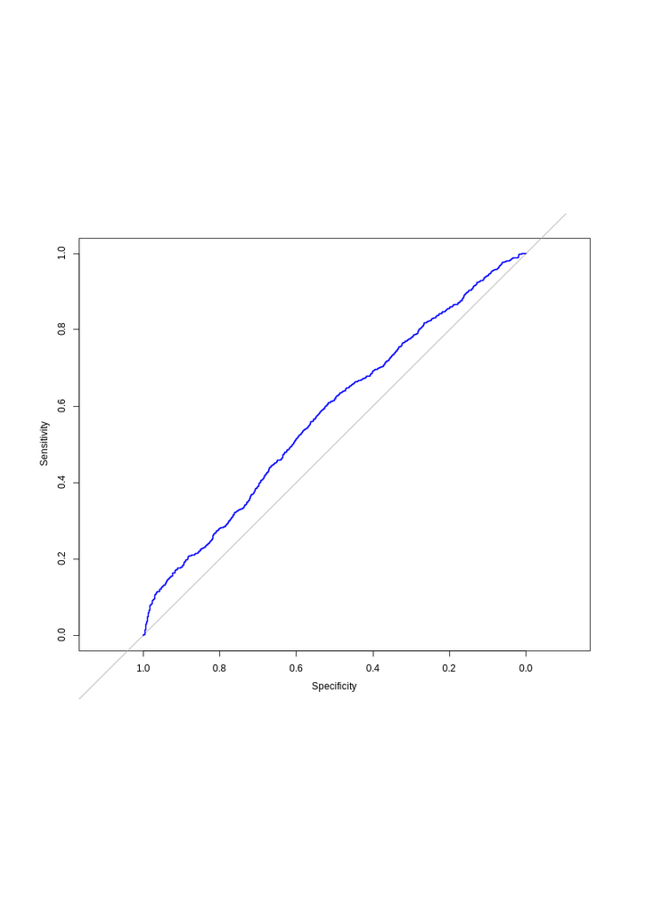

ROC Curve - PCA/t-SNE Data

Performance collapsed to **AUC = 0.578** — barely better than chance. This is the central finding of Part 1: PCA and t-SNE compress the continuous variables into a low-dimensional summary optimized for *visualizing overall structure*, not for preserving the specific signal that separates defaulters from non-defaulters. When the original financial variables are removed entirely, most of the predictive information is lost.

### Conclusion — Part 1

Dimensionality reduction is valuable here for exploration and visualization, but not as a substitute for the original features in a predictive model. The best-performing model by far used the full, original feature set (AUC 0.914); reducing to two PCA dimensions and a handful of t-SNE coordinates discarded the specific debt, delinquency, and credit-history signals that actually drive default risk.

## Part 2 — PCA + K-Means Cluster Analysis

Four continuous variables sharing a common financial theme — mortgage amount, home value, credit age, and debt-to-income ratio (`IMP_MORTDUE`, `IMP_VALUE`, `IMP_CLAGE`, `IMP_DEBTINC`) — were reduced via PCA and then clustered with K-Means to identify natural borrower segments.

Scree Plot

PC1 vs PC2

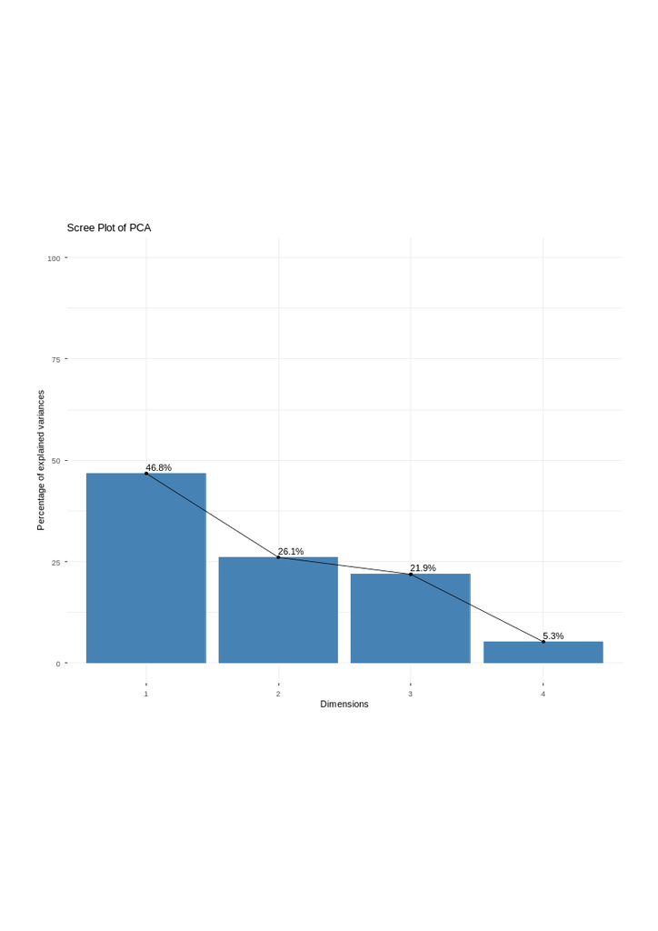

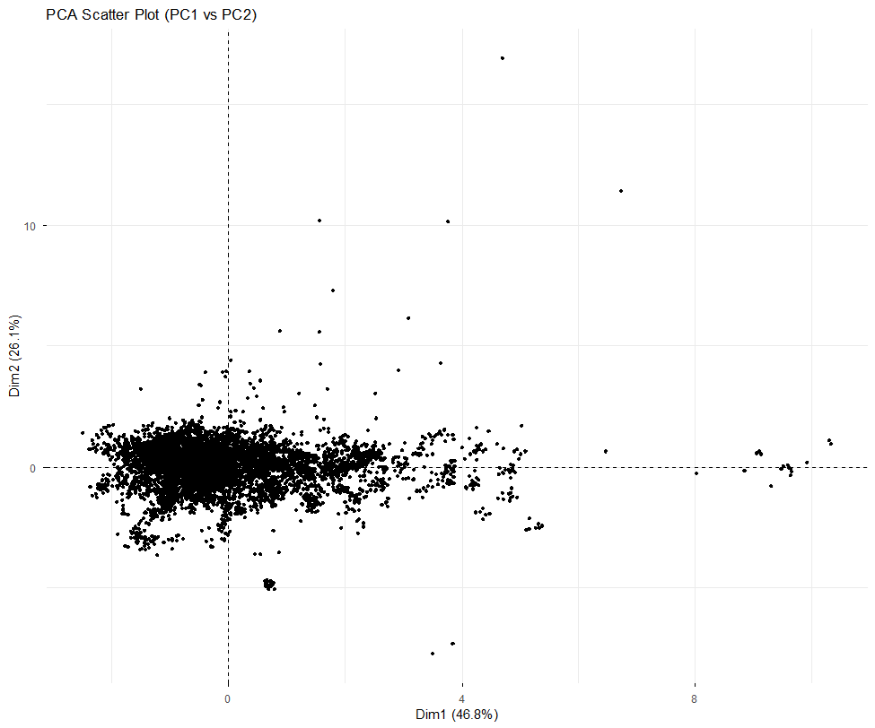

The first two components explain about 73% of the variance (46.8% + 26.1%), a reasonable basis for clustering in 2D.

### Choosing k and fitting K-Means

Elbow Plot

Cluster Sizes

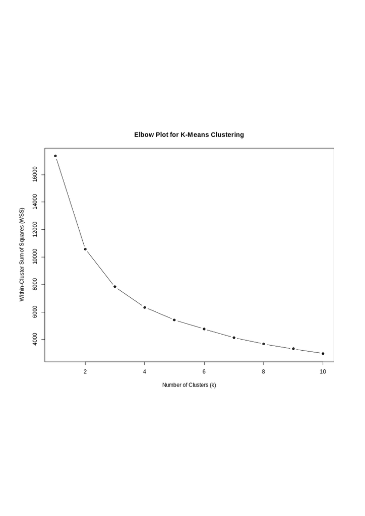

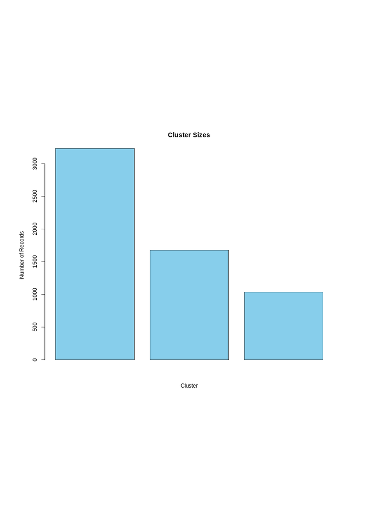

The within-cluster sum of squares flattens out around **k = 3**. The resulting clusters are uneven in size: Cluster 1 (~3,240 records) is the largest and most typical group, Cluster 2 (~1,681 records) is a moderate-size group, and Cluster 3 (~1,039 records) is the smallest and most distinct.

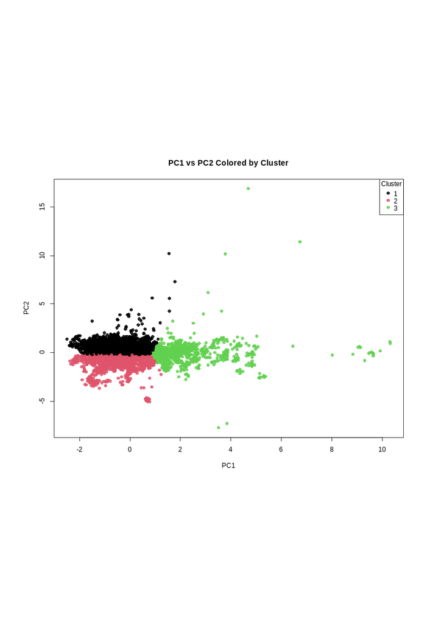

PC1 vs PC2 by Cluster

### Describing the clusters with a decision tree

A decision tree fit on the four original variables (predicting cluster membership) makes the clusters interpretable in plain financial terms:

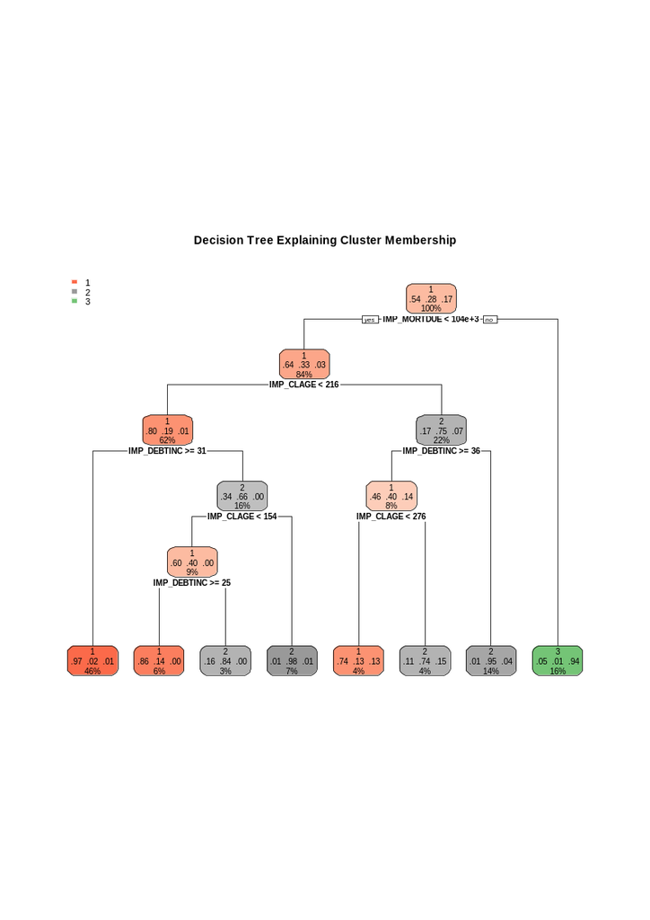

Decision Tree Explaining Cluster Membership

- **Cluster 1 — Higher-risk, high debt burden.** Lower mortgage amounts, higher debt-to-income ratios (`IMP_DEBTINC ≥ 31`), and shorter credit history. Financially more strained borrowers.
- **Cluster 2 — Moderate risk, average profile.** Moderate debt-to-income (below ~36), mid-range credit age, and modest mortgage values. A middle-risk group with more stable finances than Cluster 1.
- **Cluster 3 — Lower risk, strong financial profile.** High mortgage values, low debt-to-income ratios, and long credit history. The most financially secure segment.

### Conclusion — Part 2

The three clusters align with intuitive borrower-risk tiers, and the splits used to describe them (debt-to-income ratio, mortgage value, credit age) match well-known drivers of credit risk. In a corporate lending setting, Cluster 1 could be flagged for closer monitoring or stricter terms, Cluster 2 treated as a standard-risk segment, and Cluster 3 targeted for premium products or higher credit limits.

## References

- Hlinka, J., Berk, M., Brosch, K., Demro, C., Fortea, L., Malt, U., & Meinert, S. (2024). Principal component analysis as an efficient method for capturing multivariate brain signatures of complex disorders — ENIGMA study in people with bipolar disorders and obesity. *Human Brain Mapping*, 45(8), 1–16. https://doi.org/10.1002/hbm.26682
- Junthopas, W., & Wongoutong, C. (2025). Pre-determining the optimal number of clusters for k-means clustering using the parameters package in R and distance metrics. *Applied Sciences*, 15(21), 11372. https://doi.org/10.3390/app152111372
- Ovchinnikova, S., & Anders, S. (2024). Simple but powerful interactive data analysis in R with R/LinkedCharts. *Genome Biology*, 25(1), 1–17. https://doi.org/10.1186/s13059-024-03164-3
- Zhang, W., Ge, Y., Liu, G., Qi, W., Xu, S., Peng, Z., & Li, Y. (2023). Clustering and decision tree-based analysis of typical operation modes of power systems. *Energy Reports*, 9, 60–69. https://doi.org/10.1016/j.egyr.2023.04.258

## License

MIT — see LICENSE.